# FIFA World Cup 2026 Prediction Model

### Overview

Ratings and predictions for the 48 finalists, built from international results up to 10 June 2026, a Dixon-Coles corrected Poisson match engine, and 100,000 simulated tournaments.

### 1. Imports

```python
import pandas as pd

from wcmodel.team_data import *
from wcmodel.match import *
from wcmodel.tournament import *
from wcmodel.charts import *

pd.set_option('display.max_rows', 100)
pd.set_option('display.max_columns', 50)
pd.set_option('display.width', 200)

wc_team_stats = build_all_team_data()
match_sim = MatchSimulator(wc_team_stats)
tournament_sim = TournamentSimulator(match_sim, group_fixtures, knockout_slots)
forecast = TournamentForecast(tournament_sim)
```

```python
progression = load_csv('100k_monte_carlo/progression_table.csv', index_col = 'Team')
group_escape = load_csv('100k_monte_carlo/group_escape.csv', index_col = 'Team')
bracket = load_csv('100k_monte_carlo/likely_bracket.csv', index_col = 'Match')
odds = load_csv('100k_monte_carlo/progression_table.csv', index_col = 'Team')['Win']
ratings = load_csv('100k_monte_carlo/team_stats.csv', index_col = 'team')
polymarket = load_csv('wc_2026_polymarket_odds.csv')
distribution = load_csv('100k_monte_carlo/scoreline_distribution.csv')
```

### 2. The Data

#### 2.1 Match Window

5,328 fixtures between 1 June 2021 and the 10 June 2026 freeze, every senior international played in the window. Each appears twice in the match table, once from each team's side, which is the shape the rating solve wants.

Goals per game is flat across the window, with no trend worth modelling. That is useful, as it means recency weighting is about which teams are good now, not about the game itself changing. 2021 and 2026 are part years, which is why their counts are lower.

```python
df = build_team_match_data()

fixtures = df[df['is_home']].copy()
fixtures['total_goals'] = fixtures['goals_scored'] + fixtures['goals_conceded']

by_year = fixtures.groupby(fixtures['date'].dt.year).agg(
    fixtures = ('date', 'size'), goals_per_game = ('total_goals', 'mean')).round(2)
display(style_table(by_year, percent = False))
```

|  | fixtures | goals_per_game |
| --- | --- | --- |
| 2021 | 899 | 2.73 |
| 2022 | 954 | 2.51 |
| 2023 | 983 | 2.76 |
| 2024 | 1211 | 2.62 |
| 2025 | 975 | 2.82 |
| 2026 | 306 | 2.74 |

#### 2.2 Home Advantage

The raw home gap is 65%, far larger than the 1.1778 the model fits. Most of it isn't home advantage. Hosts are usually the stronger side, by 48.7 Elo at home venues against 16.5 at neutral ones, mostly from friendlies, where the host arranges the fixture and picks the opponent. Once the ratings account for who was playing, about 18% is left.

```python
fixtures['elo_gap'] = fixtures['elo'] - fixtures['opponent_elo']

venue = fixtures.groupby('neutral').agg(
    fixtures = ('date', 'size'), home_goals = ('goals_scored', 'mean'),
    away_goals = ('goals_conceded', 'mean'), elo_gap = ('elo_gap', 'mean')).round(2)
venue.index = ['home venue', 'neutral']
display(style_table(venue, percent = False))
```

|  | fixtures | home_goals | away_goals | elo_gap |
| --- | --- | --- | --- | --- |
| home venue | 3523 | 1.70 | 1.03 | 48.68 |
| neutral | 1805 | 1.39 | 1.24 | 16.51 |

#### 2.3 How Much Each Team Plays

Match counts across the 48 finalists range from 45 to 98. A team with 45 results has a noisier estimate than one with 98, which is why the Elo prior exists.

```python
counts = df[df['team'].isin(get_wc_teams())].groupby('team').size()

played = pd.concat([counts.nlargest(5), counts.nsmallest(5)]).to_frame('Matches')
display(style_table(played, group_size = 5, percent = False))
```

|  | Matches |
| --- | --- |
| Mexico | 98 |
| USA | 88 |
| Panama | 86 |
| Saudi Arabia | 86 |
| Morocco | 83 |
| Curaçao | 45 |
| New Zealand | 46 |
| Haiti | 50 |
| Bosnia and Herzegovina | 51 |
| Norway | 53 |

#### 2.4 Match Weights

Every fixture carries a weight combining time decay and tournament importance, running from 1.3 to 32.7 with a median of 6.8. A recent competitive match counts for roughly 25 times a distant friendly.

```python
display(style_table(fixtures['weight'].describe()[['min', '50%', 'max']].to_frame(), percent = False))
```

|  | weight |
| --- | --- |
| min | 1.31 |
| 50% | 6.84 |
| max | 32.74 |

The heaviest fixture in the data is Morocco's 3-0 win over Senegal at the 2025 African Cup of Nations final, which was awarded via forfeit after Senegal had won 1-0 but walked off the pitch in protest at one point in the game. The result stands in Morocco's favour, but a rating system built on goals reads it as a three goal performance against a strong opponent, which is a flaw in the approach rather than an error in the data. Correcting it to the 1-0 on the pitch would improve Senegal's defence rating by 13.3%.

```python
corrected = df.copy()
match = corrected['date'] == '2026-01-18'
morocco = match & (corrected['team'] == 'Morocco') & (corrected['opponent'] == 'Senegal')
senegal = match & (corrected['team'] == 'Senegal') & (corrected['opponent'] == 'Morocco')

corrected.loc[morocco, ['goals_scored', 'goals_conceded']] = [0, 1]
corrected.loc[senegal, ['goals_scored', 'goals_conceded']] = [1, 0]

teams, columns = ['Morocco', 'Senegal'], ['attack_rating', 'defence_rating']

awarded = ratings.loc[teams, columns].stack()
played = build_all_team_data(corrected).loc[teams, columns].stack()

impact = pd.DataFrame({'awarded' : awarded, 'played' : played, 'change' : played / awarded - 1})
impact.index = [f'{team} {column.split("_")[0]}' for team, column in impact.index]
display(style_table(impact, percent = False).format(
    {'awarded' : '{:.2f}', 'played' : '{:.2f}', 'change' : '{:+.1%}'}))
```

|  | awarded | played | change |
| --- | --- | --- | --- |
| Morocco attack | 1.81 | 1.74 | -3.9% |
| Morocco defence | 0.43 | 0.46 | +6.1% |
| Senegal attack | 1.62 | 1.64 | +1.6% |
| Senegal defence | 0.64 | 0.56 | -13.3% |

### 3. Team Ratings

Everything the forecast says traces back to two numbers per team, so this is where most of the error comes from.

In order to calculate the offensive and defensive strengths of each team, every match is weighted by exponential time decay and by how important the competition was. This gives more importance to goals scored or conceded in competitive games as well as games that have been played more recently, and less to those from friendlies and games further in the past.

This is subsequently factored alongside the squad market values and the average Elo of each nation across this time period to create individual stats. The 'current Elo' value is the World Football Elo for each team as of 10/06/2026.

**Match weight:**

$$w = e^{-\lambda \cdot \text{days ago}} \times \text{importance}, \qquad \lambda = 0.00095$$

**Attack and defence, solved together:**

$$\text{attack}_i = \frac{\sum_j w_{ij}\,\text{goals scored}_{ij}}{\sum_j w_{ij}\,\text{defence}_j}, \qquad \text{defence}_i = \frac{\sum_j w_{ij}\,\text{goals conceded}_{ij}}{\sum_j w_{ij}\,\text{attack}_j}$$

**The blend:**

Attack is a weighted geometric mean of the three sources:

$$\log(\text{attack}) = 0.60 \cdot \log(\text{solved}) + 0.10 \cdot \log(\text{raw rate}) + 0.30 \cdot \log(\text{Elo prior})$$

Then the spread is compressed and squad value applied, where $v$ is standardised log squad market value:

$$\text{attack} \rightarrow \text{attack}^{\,0.84} \cdot e^{\,0.07\,v}$$

Defence follows the same two steps, with the Elo prior and the squad value both reversed in sign, since a stronger team should concede fewer.

```python
ratings['attack_rank'] = ratings['attack_rating'].rank(ascending = False, method = 'min').astype(int)
ratings['defence_rank'] = ratings['defence_rating'].rank(ascending = True, method = 'min').astype(int)
ratings['elo_rank'] = ratings['current_elo'].rank(ascending = False, method = 'min').astype(int)

stats = ratings[['attack_rating','attack_rank', 'defence_rating', 'defence_rank', 'current_elo', 'elo_rank']].rename_axis(None)


stats.style.format({
    'attack_rating'    : '{:.2f}',
    'defence_rating' : '{:.2f}',
    'current_elo' : '{:.0f}',
})
```

|  | attack_rating | attack_rank | defence_rating | defence_rank | current_elo | elo_rank |
| --- | --- | --- | --- | --- | --- | --- |
| Spain | 3.07 | 1 | 0.41 | 3 | 2157 | 1 |
| Argentina | 2.54 | 5 | 0.36 | 1 | 2115 | 2 |
| France | 2.65 | 2 | 0.46 | 5 | 2063 | 3 |
| England | 2.51 | 6 | 0.38 | 2 | 2024 | 4 |
| Brazil | 2.39 | 8 | 0.46 | 6 | 1991 | 5 |
| Portugal | 2.63 | 4 | 0.51 | 9 | 1989 | 6 |
| Colombia | 2.16 | 10 | 0.55 | 10 | 1982 | 7 |
| Netherlands | 2.50 | 7 | 0.56 | 11 | 1948 | 8 |
| Ecuador | 1.41 | 27 | 0.47 | 7 | 1938 | 9 |
| Germany | 2.64 | 3 | 0.57 | 13 | 1932 | 10 |
| Norway | 2.36 | 9 | 0.65 | 18 | 1914 | 11 |
| Croatia | 1.99 | 13 | 0.60 | 15 | 1912 | 12 |
| Turkey | 1.91 | 14 | 0.79 | 29 | 1911 | 13 |
| Japan | 1.88 | 15 | 0.59 | 14 | 1906 | 14 |
| Belgium | 2.09 | 11 | 0.57 | 12 | 1894 | 15 |
| Uruguay | 1.62 | 20 | 0.48 | 8 | 1892 | 16 |
| Switzerland | 2.03 | 12 | 0.67 | 19 | 1891 | 17 |
| Mexico | 1.37 | 30 | 0.62 | 16 | 1875 | 18 |
| Senegal | 1.62 | 19 | 0.64 | 17 | 1860 | 19 |
| Paraguay | 1.27 | 32 | 0.73 | 21 | 1834 | 20 |
| Austria | 1.75 | 17 | 0.68 | 20 | 1830 | 21 |
| Morocco | 1.81 | 16 | 0.43 | 4 | 1827 | 22 |
| Canada | 1.42 | 26 | 0.79 | 30 | 1788 | 23 |
| Scotland | 1.58 | 22 | 0.81 | 31 | 1782 | 24 |
| Australia | 1.38 | 29 | 0.74 | 22 | 1777 | 25 |
| Algeria | 1.52 | 24 | 0.77 | 26 | 1772 | 26 |
| Iran | 1.39 | 28 | 0.91 | 35 | 1772 | 26 |
| South Korea | 1.51 | 25 | 0.87 | 34 | 1758 | 28 |
| Czech Republic | 1.56 | 23 | 0.84 | 33 | 1740 | 29 |
| Panama | 1.16 | 33 | 1.19 | 45 | 1730 | 30 |
| USA | 1.58 | 21 | 0.77 | 27 | 1726 | 31 |
| Uzbekistan | 1.08 | 38 | 0.78 | 28 | 1714 | 32 |
| Sweden | 1.75 | 18 | 0.91 | 36 | 1712 | 33 |
| Egypt | 1.14 | 34 | 0.75 | 23 | 1696 | 34 |
| Côte d'Ivoire | 1.30 | 31 | 0.76 | 25 | 1695 | 35 |
| Jordan | 1.11 | 35 | 1.19 | 44 | 1680 | 36 |
| DR Congo | 1.00 | 41 | 0.76 | 24 | 1652 | 37 |
| Tunisia | 1.08 | 37 | 0.81 | 32 | 1628 | 38 |
| Iraq | 0.91 | 44 | 1.08 | 39 | 1607 | 39 |
| Bosnia and Herzegovina | 1.05 | 40 | 1.13 | 42 | 1595 | 40 |
| Cabo Verde | 0.87 | 45 | 1.17 | 43 | 1578 | 41 |
| Saudi Arabia | 0.85 | 46 | 0.97 | 37 | 1576 | 42 |
| New Zealand | 0.82 | 47 | 1.08 | 40 | 1562 | 43 |
| Haiti | 0.93 | 43 | 1.54 | 47 | 1548 | 44 |
| South Africa | 1.05 | 39 | 1.07 | 38 | 1517 | 45 |
| Ghana | 1.10 | 36 | 1.11 | 41 | 1510 | 46 |
| Curaçao | 0.71 | 48 | 1.55 | 48 | 1434 | 47 |
| Qatar | 1.00 | 42 | 1.50 | 46 | 1421 | 48 |

Before the `WORLD_CUP_BASELINE` is factored in, the mean value of goals per team per game is calculated as:

$$\bar{x} = \frac{1}{2N}\sum_{\text{fixtures}} \left( \text{attack}_{\text{home}} \cdot \text{defence}_{\text{away}} + \text{attack}_{\text{away}} \cdot \text{defence}_{\text{home}} \right)$$

where $N$ is the number of fixtures, so $2N$ counts each team's side of each match.

Across the 72 group fixtures this comes out at 1.302 goals per team per game, or 2.604 per match. Multiplying by the baseline of 1.0559 lifts that to 1.375 per team, or 2.750 per match over 90 minutes.

```python
ratings[["attack_rating", "defence_rating"]].mean()
```

```
attack_rating     1.605635
defence_rating    0.792482
dtype: float64
```

A team's expected goals are its attack multiplied by its opponent's defence. The axes are correlated, since strong teams tend to be strong at both ends. Generally, the low Elo teams have worse stats than the high Elo teams.

Four teams sit more than two standard deviations from the mean. Spain on attack, and Haiti, Curaçao and Qatar on defence.

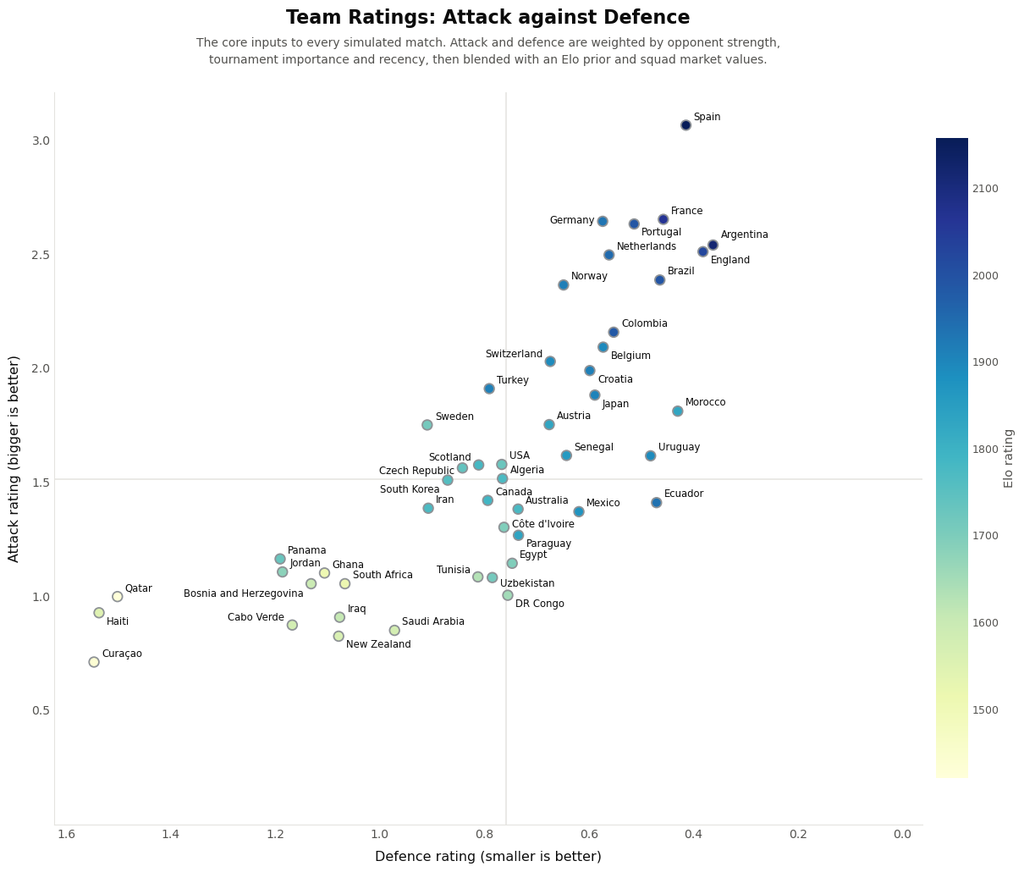

```python
stat_fig = plot_team_ratings(ratings)
```

### 4. Group Escape Probabilities

A team's probability of winning its group, and of escaping it, over 100,000 Monte Carlo simulations. 32 of the 48 teams reach the knockout stages. That is the top two from each group, plus the eight best third placed teams.

This is the first output where the tie breakers and the third place rankings matter, rather than the match engine alone.

```python
display(style_table(group_escape, group_size = 4))
```

|  | Group | Win group | Escape |
| --- | --- | --- | --- |
| Mexico | A | 50.1% | 91.2% |
| Czech Republic | A | 23.9% | 75.9% |
| South Korea | A | 20.7% | 72.1% |
| South Africa | A | 5.3% | 34.8% |
| Switzerland | B | 57.7% | 97.5% |
| Canada | B | 36.8% | 93.9% |
| Bosnia and Herzegovina | B | 4.2% | 48.5% |
| Qatar | B | 1.3% | 23.3% |
| Brazil | C | 55.6% | 98.6% |
| Morocco | C | 35.7% | 96.2% |
| Scotland | C | 8.5% | 75.7% |
| Haiti | C | 0.2% | 6.1% |
| USA | D | 38.0% | 81.9% |
| Turkey | D | 30.4% | 76.0% |
| Australia | D | 17.1% | 61.1% |
| Paraguay | D | 14.4% | 55.8% |
| Germany | E | 65.4% | 99.2% |
| Ecuador | E | 25.3% | 92.7% |
| Côte d'Ivoire | E | 9.1% | 76.6% |
| Curaçao | E | 0.2% | 6.0% |
| Netherlands | F | 57.1% | 94.3% |
| Japan | F | 29.2% | 84.5% |
| Sweden | F | 9.8% | 56.6% |
| Tunisia | F | 3.9% | 34.0% |
| Belgium | G | 69.3% | 97.0% |
| Iran | G | 14.3% | 71.3% |
| Egypt | G | 13.8% | 70.4% |
| New Zealand | G | 2.6% | 28.3% |
| Spain | H | 80.0% | 99.7% |
| Uruguay | H | 18.7% | 93.0% |
| Saudi Arabia | H | 0.8% | 31.5% |
| Cabo Verde | H | 0.4% | 21.7% |
| France | I | 60.1% | 97.6% |
| Norway | I | 27.6% | 90.7% |
| Senegal | I | 11.7% | 74.0% |
| Iraq | I | 0.5% | 10.8% |
| Argentina | J | 76.5% | 99.0% |
| Austria | J | 14.9% | 82.2% |
| Algeria | J | 7.9% | 68.2% |
| Jordan | J | 0.8% | 17.9% |
| Portugal | K | 57.8% | 96.1% |
| Colombia | K | 35.1% | 90.7% |
| Uzbekistan | K | 3.6% | 37.7% |
| DR Congo | K | 3.4% | 36.5% |
| England | L | 72.7% | 99.4% |
| Croatia | L | 25.1% | 94.1% |
| Ghana | L | 1.1% | 31.1% |
| Panama | L | 1.1% | 28.9% |

### 5. Knockout Progression Table

The share of the 100,000 tournaments each team reached a given round in, carried through to the end, where the bracket structure starts to matter more than the ratings.

Spain win the most at 18.6%, Argentina come second at 14.6%. The top 4 teams make up over 50% of the simulated World Cup titles.

```python
display(style_table(progression))
```

|  | Win | Reach Final | Reach Semi | Reach Quarter | Reach R16 |
| --- | --- | --- | --- | --- | --- |
| Spain | 18.6% | 29.4% | 43.1% | 54.7% | 75.7% |
| Argentina | 14.6% | 24.2% | 38.0% | 53.5% | 66.8% |
| England | 13.2% | 22.1% | 36.2% | 54.6% | 75.5% |
| France | 9.5% | 17.5% | 31.1% | 48.7% | 74.0% |
| Portugal | 7.2% | 14.3% | 26.1% | 45.7% | 69.5% |
| Brazil | 6.5% | 12.7% | 24.4% | 42.7% | 65.2% |
| Germany | 4.9% | 10.4% | 21.2% | 37.1% | 68.3% |
| Netherlands | 4.0% | 8.6% | 18.2% | 34.4% | 50.4% |
| Morocco | 3.6% | 8.0% | 17.3% | 33.9% | 55.8% |
| Colombia | 2.7% | 6.8% | 15.0% | 29.1% | 54.6% |
| Belgium | 2.7% | 7.1% | 15.9% | 40.5% | 68.5% |
| Norway | 2.0% | 5.3% | 12.8% | 27.1% | 53.0% |
| Uruguay | 1.6% | 4.5% | 10.9% | 22.5% | 39.9% |
| Croatia | 1.6% | 4.4% | 10.7% | 21.7% | 49.0% |
| Switzerland | 1.2% | 3.6% | 10.0% | 27.0% | 65.1% |
| Ecuador | 1.1% | 3.1% | 8.2% | 19.7% | 46.4% |
| Japan | 1.0% | 3.0% | 8.0% | 18.8% | 35.4% |
| Mexico | 0.8% | 2.5% | 7.4% | 21.0% | 53.8% |
| USA | 0.8% | 2.6% | 7.3% | 21.7% | 50.3% |
| Austria | 0.5% | 1.6% | 4.8% | 12.5% | 27.9% |
| Senegal | 0.4% | 1.4% | 4.5% | 13.6% | 32.2% |
| Turkey | 0.4% | 1.4% | 4.7% | 16.1% | 42.8% |
| Canada | 0.3% | 1.2% | 4.6% | 17.2% | 52.3% |
| Australia | 0.1% | 0.5% | 2.2% | 8.3% | 27.8% |
| Czech Republic | 0.1% | 0.6% | 2.3% | 10.1% | 34.7% |
| Scotland | 0.1% | 0.5% | 2.2% | 8.1% | 25.7% |
| Algeria | 0.1% | 0.5% | 2.0% | 7.1% | 19.8% |
| Côte d'Ivoire | 0.1% | 0.4% | 1.6% | 6.9% | 25.7% |
| Paraguay | 0.1% | 0.4% | 1.6% | 6.6% | 23.5% |
| South Korea | 0.1% | 0.4% | 1.8% | 8.5% | 31.0% |
| Egypt | 0.1% | 0.3% | 1.4% | 6.6% | 26.6% |
| Sweden | 0.0% | 0.3% | 1.2% | 4.6% | 13.5% |
| Iran | 0.0% | 0.2% | 1.1% | 6.0% | 26.1% |
| Uzbekistan | 0.0% | 0.1% | 0.5% | 2.2% | 8.3% |
| DR Congo | 0.0% | 0.1% | 0.5% | 2.1% | 8.0% |
| Tunisia | 0.0% | 0.1% | 0.3% | 1.6% | 6.2% |
| South Africa | 0.0% | 0.0% | 0.1% | 1.5% | 8.7% |
| Ghana | 0.0% | 0.0% | 0.1% | 0.7% | 4.1% |
| Bosnia and Herzegovina | 0.0% | 0.0% | 0.2% | 1.9% | 12.0% |
| Jordan | 0.0% | 0.0% | 0.0% | 0.4% | 2.4% |
| Qatar | 0.0% | 0.0% | 0.0% | 0.3% | 3.5% |
| Saudi Arabia | 0.0% | 0.0% | 0.1% | 0.9% | 5.7% |
| Iraq | 0.0% | 0.0% | 0.0% | 0.3% | 1.5% |
| Haiti | 0.0% | 0.0% | 0.0% | 0.0% | 0.5% |
| Panama | 0.0% | 0.0% | 0.1% | 0.6% | 3.5% |
| New Zealand | 0.0% | 0.0% | 0.0% | 0.6% | 5.2% |
| Curaçao | 0.0% | 0.0% | 0.0% | 0.0% | 0.4% |
| Cabo Verde | 0.0% | 0.0% | 0.0% | 0.4% | 3.0% |

### 6. Knockout Bracket

#### 6.1 Bracket Visualisation

Each tie shows the team most likely to progress from it across the 100,000 tournaments, so this is 32 separate answers rather than one predicted tournament. No single bracket is likely enough to be worth predicting.

The eight third placed teams in this bracket are the ones with the highest escape percentages over 100,000 simulations.

[figure not shown]

```python
bracket_fig = plot_bracket(bracket, knockout_slots, odds)
```

#### 6.2 Bracket Conflicts

The bracket picks each tie by how often a team progresses across every simulation, which isn't the same as who would win the tie on the day. One fixture disagrees. Morocco progress from the round of 32 more often than the Netherlands do, but in a head to head between them the Netherlands are favourites.

That happens because the two teams don't arrive in that slot equally often. Morocco reach it against a wider range of opponents, so their progression rate is averaged over ties they would usually be favoured in, while the specific Netherlands fixture is one they'd usually lose.

```python
venues = load_csv('knockout_slots.csv').set_index('match_id')['venue']

conflicts = []

for match_id, row in bracket.iterrows():
    prob = match_sim.match_probabilities(row['Home'], row['Away'], venue = venues[match_id], stage = 'knockout')
    h2h = row['Home'] if prob['home_advances'] >= prob['away_advances'] else row['Away']

    if h2h != row['Winner']:
        conflicts.append({
            'Match' : match_id,
            'Round' : row['Round'],
            'Tie' : f"{row['Home']} vs. {row['Away']}",
            'Bracket winner' : row['Winner'],
            'Head-to-head winner' : h2h
        })

if conflicts:
       display(style_table(pd.DataFrame(conflicts).set_index('Match'), percent = False))
else:
        print('No conflicts: every tie matches the head-to-head favourite.')
```

|  | Round | Tie | Bracket winner | Head-to-head winner |
| --- | --- | --- | --- | --- |
| 75 | Round of 32 | Netherlands vs. Morocco | Morocco | Netherlands |

### 7. Market vs Monte Carlo

Champion odds against Polymarket prices on the same date. The market isn't a correct answer to check against, it's another forecast, so a gap only says the two disagree and not which one is wrong. The model does not claim to be more precise than the market. Prices sum to 102.2%, so the market numbers are slightly inflated before any comparison.

The model is very low on France compared to the market, at 9.5% against 16.2%, and high on Argentina at 14.6% against 8.8%. Everything outside the top six sits within two points.

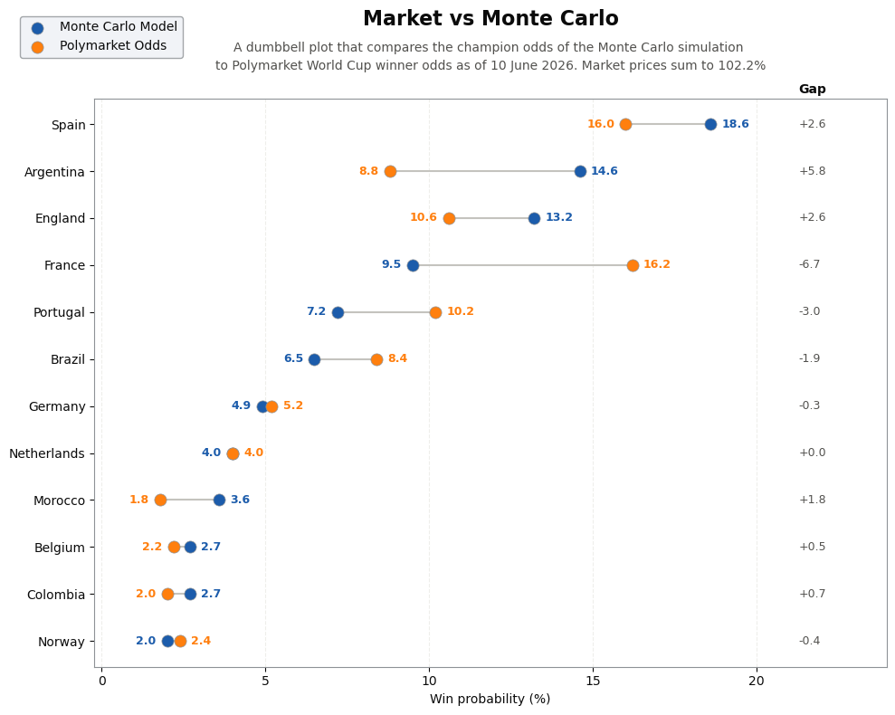

```python
comparison_df, fig = plot_market_comp(progression, polymarket, top_n = 12)
```

### 8. Probability Heatmaps

#### 8.1 Group Stage

The full scoreline distribution for one fixture, taken from the engine rather than counted from simulations. Each cell is the probability of that exact score.

Mexico open the tournament at home, so their expected goals carry the host boost. The two most likely scores are 1-0 and 2-0.

[figure not shown]

```python
heatmap_gs_fig = plot_heatmap(match_sim, 'Mexico', 'South Africa', venue = 'Estadio Azteca, Mexico City',  stage = 'group', save = True)
```

#### 8.2 Knockout Stage

The same chart for a knockout tie, so the scores are at the end of the tie rather than after 90 minutes and there is no draw column. The scores along the diagonal go to a penalty shootout, which the model treats as a coin flip.

Spain against Argentina is the final the likely bracket predicts, and is evenly matched. Spain narrowly win the majority of simulations with a 51.8% win probability, and the most common scoreline is 1-0 Spain.

[figure not shown]

```python
heatmap_ko_fig = plot_heatmap(match_sim, 'Spain', 'Argentina', venue = 'MetLife Stadium, East Rutherford', stage = 'knockout', save = True)
```

### 9. Scoreline Distribution

Simulated 2026 scorelines against every World Cup match since 1998. It shows where the model is visibly wrong in its simulations, and why.

The model underpredicts scorelines such as 1-0 and 2-1, and makes up the difference in wider margins like 3-0 and 4-0. The labels above each pair are model minus observed.

That is how independent Poisson works. Goals are drawn separately for each side, so nothing tells the model that a leading team plays more defensively. Dixon-Coles only reaches the four lowest scoring cells, and with a negative rho it lifts 0-0 and 1-1 while pushing 1-0 down, so it works against the scoreline the model is already shortest on.

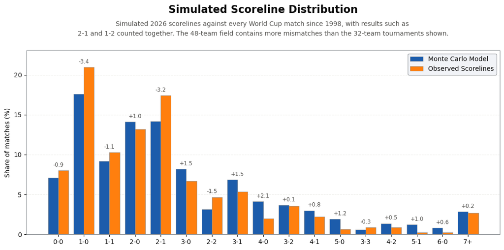

```python
scores_fig = plot_scorelines(distribution)
```

### 10. Conclusion

Spain wins 18.6% of all simulations and Argentina wins 14.6%, with the top four taking just over half the simulated titles between them. Every value in here existed before the tournament kicked off.

Where the model is weakest is in the goal margins, and in the fact that a single forfeited game can significantly move a team's stats. How it actually performed relative to the 2026 World Cup is in the README.